# Mini-Lab-simulation-theta-xbar

Lane Quigley

February 6, 2019

# Introduction

We will investigate the distribution of $\theta$ made so that $\tilde{s}_{12}=0$ (looking only at the first clockwise root solution in radians) and the distribution of $\bar{X}$, the sample mean.

This will be done by simulation.

# Method and tasks

## Function name and parameters

Call the function `xbarthetadist()` make it take arguments `n` the sample size, $iter$ the number of iterations, $\mu$ the population mean vector (2X1) and the var-cov matrix (2X2). You may wish to pass other arguments.

## `theta`

There are various ways to find theta – the most alegant is to use the analytical solution which is what we will use here.

## Tasks

Make a function that does the following:

1. Repeatedly simulates a sample of size $n$ from a bivariate normal that has mean $\mu$ and variance covariance matrix $\Sigma$.
2. Uses each sample to calculate $\bar{X}$ and $\theta$
3. Stores these values appropriately
4. Makes a total of 4 plots using `ggplot`:
- scatterplot and
- 2d density plot of $\bar{X}$
- a histogram and
- a density plot of $\theta$

You may wish to consult http://www.cookbook-r.com/Graphs/Multiple_graphs_on_one_page_(ggplot2)/

```r
xbarthetadist = function(n,iter,mu,sigma){
  library(mvtnorm)
  library(ggplot2)
  mat = matrix(NA, nr= iter, nc=4)
  colnames(mat)= c("xbar1","xbar2","thetae","thetar")
  for(i in 1:iter){
    x = rmvnorm(n,mu,sigma)
    mat[i,c(1,2)] <- colMeans(x)
    s=(n-1)/n*cov(x)
    eig=eigen(s)
    thetaeigen=acos(eig$vectors[,1][1])
    thetarot= .5*atan(2*s[1,2]/(s[1,1]-s[2,2])) + pi/2

    mat[i,3]<-thetaeigen
    mat[i,4]<-thetarot



  }

  df=as.data.frame(mat)
  g=ggplot(df, aes(x=xbar1,y=xbar2))  + coord_equal()

  gp = g + geom_point()
  print(gp)
  gd = g + stat_density_2d()
  print(gd)

  gt=ggplot(data=df, aes(df$thetar)) + geom_histogram() + xlab("Theta Value")
  print(gt)

  gt2 = ggplot(data=df, aes(df$thetar)) + geom_density() + xlab("Theta")
  print(gt2)
 # thetaValues = df$theta;
 # hist(thetaValues)
  #plot(density(thetaValues))

  head(mat)
}
```

# Run the function

To show the function works execute the following function calls

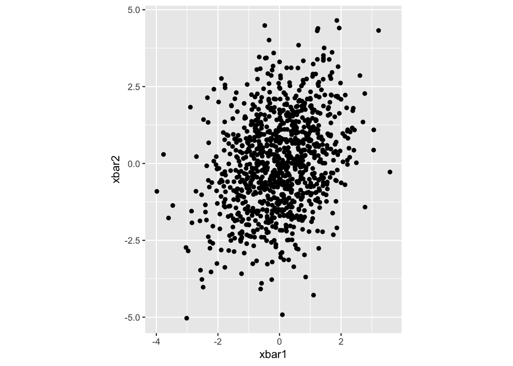

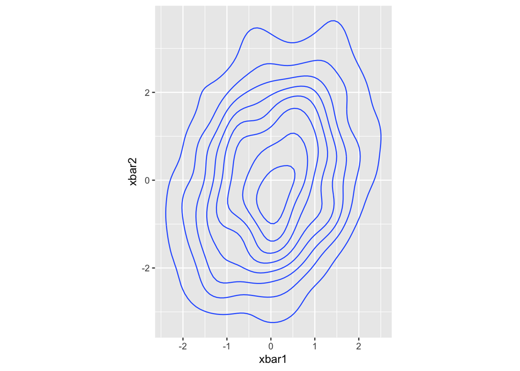

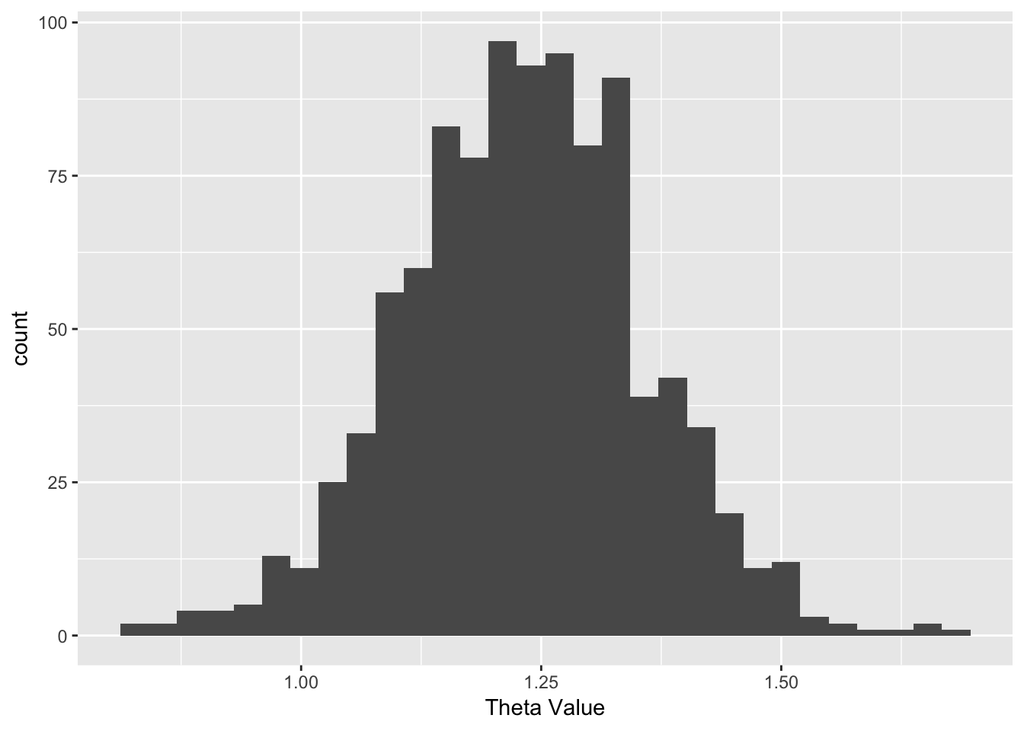

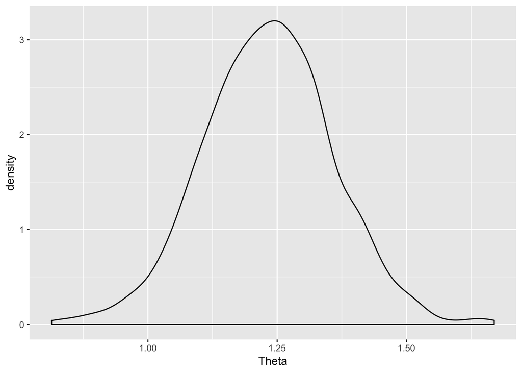

```
##           xbar1      xbar2   thetae   thetar
## [1,] -1.4034693  2.3031171 1.207203 1.207203
## [2,] -3.9840539 -0.9077197 1.260464 1.260464
## [3,] -1.8863873  2.7632318 1.249908 1.249908
## [4,] -0.4489016 -0.1576931 1.163267 1.163267
## [5,]  0.9424219 -0.9334077 1.506941 1.506941
## [6,]  0.6837134  0.2048026 1.237020 1.237020
```

```r
mu1=c(0,0)
sigma1 = matrix(c(100,40,40,200), nr=2,nc=2,byrow=FALSE)
xbarthetadist(n=80,iter=1000,mu=mu1,sigma=sigma1)
```

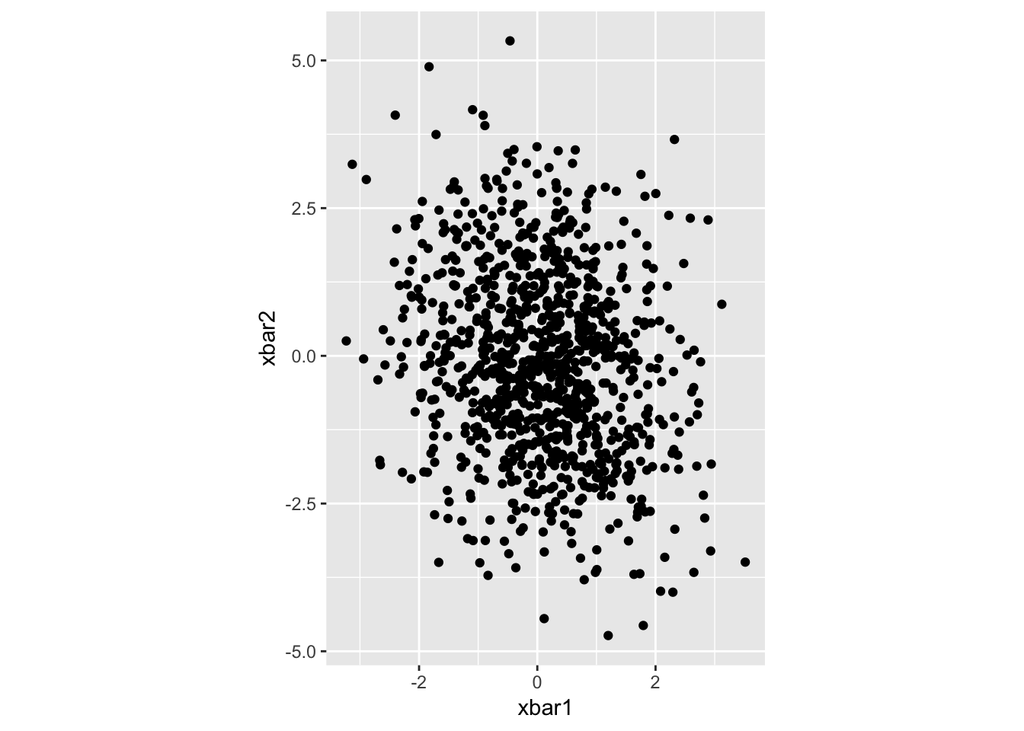

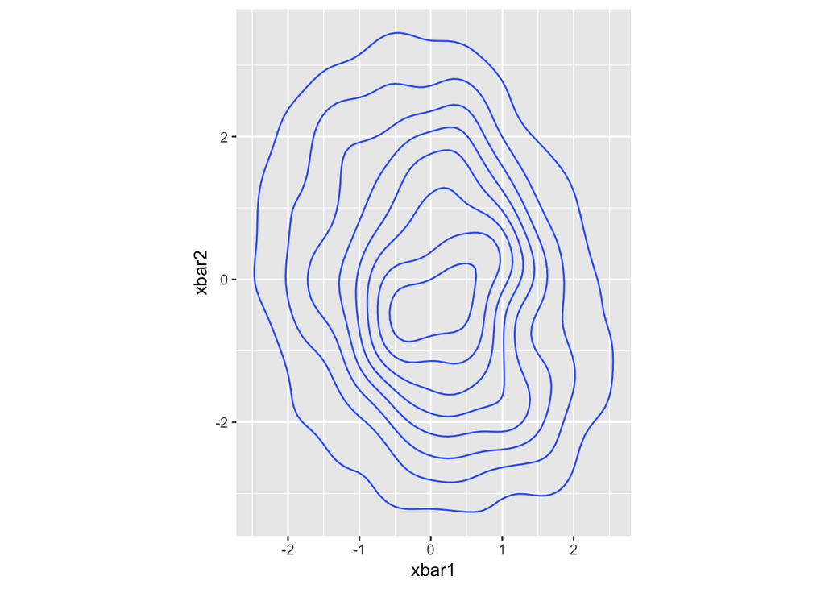

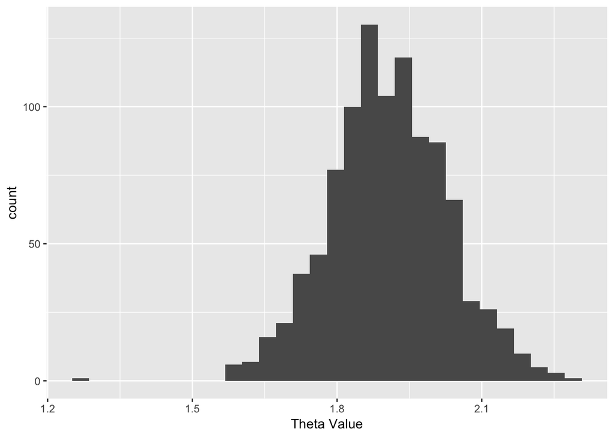

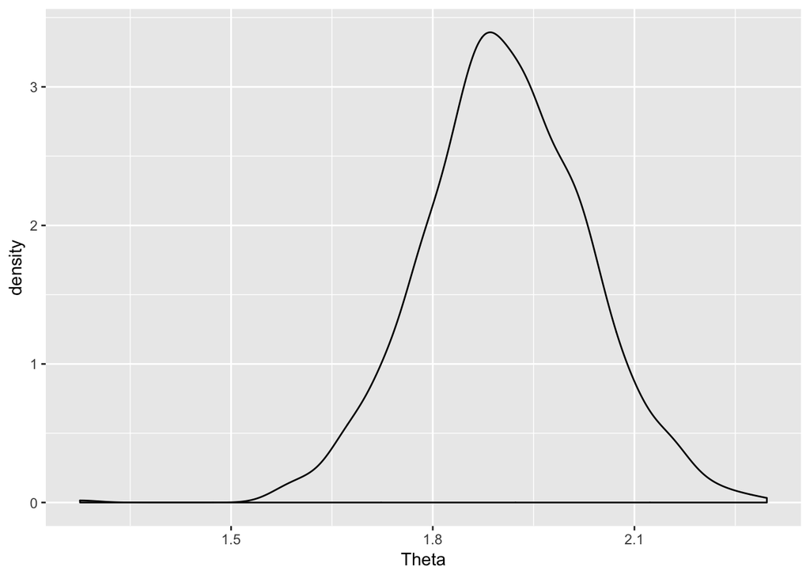

```
##           xbar1       xbar2   thetae   thetar
## [1,]  1.2810256 -2.14877021 2.103046 2.103046
## [2,]  1.4697483  0.32329161 1.672334 1.672334
## [3,]  0.3247165 -1.61213396 1.929911 1.929911
## [4,] -0.5551470  1.53162546 2.075102 2.075102
## [5,] -0.5977454  0.05943522 1.781335 1.781335
## [6,]  0.9663663  0.12396906 1.946794 1.946794
```

```r
sigma2 = matrix(c(100,-40,-40,200), nr=2,nc=2,byrow=FALSE)
xbarthetadist(n=80,iter=1000,mu=mu1,sigma=sigma2)
```

# Now make a Shiny server

Using the shiny dashboard template create widgets to input `n`, `iter`, `mu`, $\sigma_{ij}$ the output will be the plots: 2d density plot of $\bar{X}$ and histogram of $\theta$. I will leave it to you to make the suitable bounds on the widget variables (remember that the covariance matrix is symmetrical)